# 4_5976542031420329580

## Report: act_report

## 1.Introduction

In this report, I will lisr the entire communicates the insights and displays the visualization,

I've been wrangling, analyzing, and visualizing the tweet archive of Twitter user @dog rates, also known as WeRateDogs. WeRateDogs is a Twitter account that rates people's dogs and includes a funny comment about the dog.

## 2. Visualization and Insights

`First :` **What is the Common Tweet Sources ?**

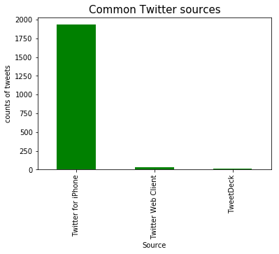

`Second:` **What is the commn dog stage ?**

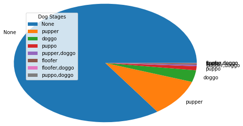

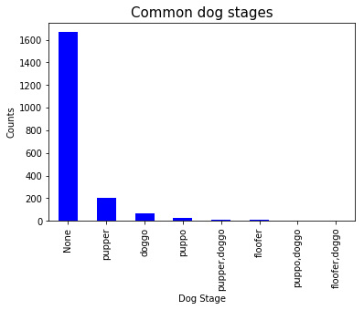

We can clearly observe a significant gap in the dog stages in the two charts above, where the most common dog stage and one with the largest number is the pupper with 201 and the lowest dog stage is the floofer,doggo with 1. From the pie chart we can see that some tweets do not include dog stage information.